# Responsible AI Use, Validation, and Reproducibility in Bioinformatics

Kelly Sovacool, PhD

Bioinformatics Software Engineer

CCR Collaborative Bioinformatics Resource

Oct 14, 2026

**Important**

This presentation was created before the directive to use the term “Super Intelligence (SI)” in place of “Artificial Intelligence (AI)”.

Always refer to the official [**NIH AI Hub**](https://nih.sharepoint.com/sites/NIH-ai/SitePages/Responsible-AI.aspx) for the most up-to-date policy information.

https://nih.sharepoint.com/sites/NIH-ai/SitePages/Responsible-AI.aspx

## Goals for this talk

- Provide background information on AI for Bioinformatics.
- Cover the NIH Responsible AI Policy.
- Equip you with practical tips for minimizing the risks of using LLMs & agents for bioinformatics.

**Take-home message**

By the end, you should feel empowered with the knowledge to **use agentic LLMs proficiently** for bioinformatics, without compromising the **quality of your science**.

## Bioinformatics is central to biomedical research

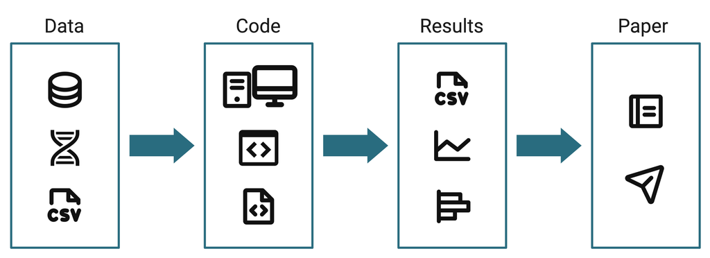

Audience roles: bioinformatician, computational biologist, data analyst, research software engineer – **anyone who writes code to analyze biological data**.

## Academic Definition of Generative AI

[figure not shown]

Image: https://www.aiforeducation.io/ai-resources/generative-ai-explainer

## Agentic LLMs have transformed software development

[figure not shown]

Image: https://orkes.io/blog/agentic-ai-explained-agents-vs-workflows

## Agentic LLMs can accelerate bioinformatics

[figure not shown]

### We can write code faster than ever before

> generate new code, troubleshoot bugs, search the web, write tests, execute code

### We can write *bad* code faster, too

> unreproducible work, incorrect methods, bugs, inefficiencies, unreadable code, lack of transparency, security vulnerabilities, malware, destructive agent actions

## NIH Responsible AI Policy

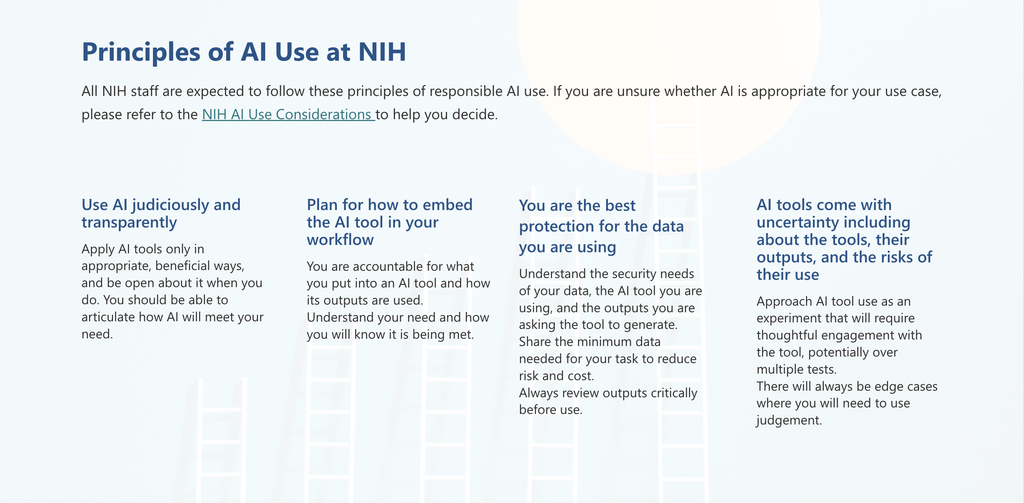

Content retrieved September 2026 from the [NIH Responsible AI site](https://nih.sharepoint.com/sites/NIH-ai/SitePages/Responsible-AI.aspx). Please refer to the official site for the latest guidance.

## NIH AI Use Checklist

**Stop and Reconsider If:**

- You cannot verify the output
- You cannot explain or justify the result
- The task involves high-stakes decisions without expert review

**1. Confirm the Use is Appropriate**

- Can you clearly state what you need, your audience (e.g., internal, external), and why AI helps?
- Do you have the time and expertise to review and adapt the output?
- Are you using a federally approved or authorized tool?

**2. Define the Human-AI Roles**

- What task is the AI performing (e.g., drafting, summarizing, classifying)?
- What decisions will you make (vs. the AI)?
- Are you prepared to be accountable for how outputs are used?

**3. Project Data and Outputs**

- Does your input data include clinical, sensitive, identifiable, or restricted information?
- Is that data allowed in the tool you are using (e.g., consistent with consent, IRB decision, agreements)?
- Are you sharing only the minimum data necessary?
- Do the outputs create new sensitivity, intellectual property, or reuse risks?

**4. Verify Outputs**

- Have you checked the facts, numbers, and citations?
- Have you tested outputs for errors, bias, or omissions?
- Would you be comfortable defending this output if questioned?

**5. Be Transparent About AI Use**

- Will others know AI was used?
- Have you documented how outputs were generated (e.g., prompts used)?
- Have you avoided presenting AI output as authoritative without review?

Content retrieved September 2026 from the [NIH AI Use Checklist](https://nih.sharepoint.com/sites/NIH-ai/SitePages/NIH-AI-Use-Checklist.aspx). Please refer to the official site for the latest guidance.

## Human in the loop

[figure not shown]

Image: https://uvik.net/blog/human-in-the-loop-ai/

## Human in driving the loop

A better way: humans judiciously use agents when appropriate to **support** human-driven tasks.

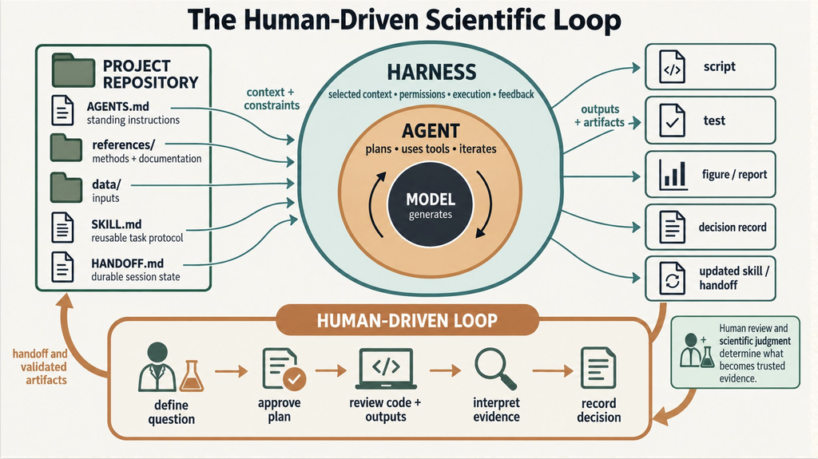

Image credit: [Samarth Mathur](https://bioinformatics.ccr.cancer.gov/btep/classes/from-scripts-to-skills-using-generative-ai-without-losing-scientific-control)

## Bioinformaticians design, develop, and execute code

**Design**

- Read scientific papers, software documentation, and forums.
- Plan how to analyze data to answer a scientific question.
- Decide how new code will accomplish the analysis plan.

**Develop**

- Write new scripts, packages, and command line tools to accomplish the analysis plan.
- Write tests to validate the code performs as expected.
- Document how the code works and how it is used to produce results.

**Execute**

- Obtain the data from the study/experiment.
- Install necessary software dependencies.
- Run the code on the data and evaluate the results.

#### *How can agents assist us in bioinformatics tasks?*

Treat agents like just another tool in your toolbox.

## Practical tips for responsible agent use

**Follow reproducible practices**

**Review, test, and validate all code**

**Document everything**

## Reproducibility is essential for science

Yourself ➡️ Future you ➡️ Your collaborators ➡️ Peers in your field

- Can each of the above people run your code on the same dataset and get the same results?
- How difficult would it be for each of them to reproduce your results?

**You are your own most important collaborator**

## Reproducible practices for responsible AI use

#### Organize your projects

- One project per directory.
- Keep data, code, and outputs in separate subdirectories.
- Data is read-only; outputs should only be written by the code.

```
file system tree
```

```
/data/$USER/projects
├── my-rnaseq-project
│   ├── AGENTS.md
│   ├── data/
│   ├── docs/
│   ├── README.md
│   ├── results/
│   ├── scripts/
│   └── tests/
└── r-dataviz-explorer
    ├── references/
    ├── scripts/
    ├── SKILL.md
    └── tests/
```

Credit to Samarth Mathur for these project examples.

## Reproducible practices for responsible AI use

#### Organize your projects

- One project per directory.
- Keep data, code, and outputs in separate subdirectories.
- Data is read-only; outputs should only be written by the code.

#### Version control & backup with git & GitHub

- Create a git repository for each project and upload it to GitHub.
- Commit meaningful code changes and sync with GitHub frequently.

```
file system tree
```

```
/data/$USER/projects
├── my-rnaseq-project
│   ├── AGENTS.md
│   ├── data/
│   ├── docs/
│   ├── README.md
│   ├── results/
│   ├── scripts/
│   └── tests/
└── r-dataviz-explorer
    ├── references/
    ├── scripts/
    ├── SKILL.md
    └── tests/
```

Credit to Samarth Mathur for these project examples.

## Reproducible practices for responsible AI use

#### Organize your projects

- One project per directory.
- Keep data, code, and outputs in separate subdirectories.
- Data is read-only; outputs should only be written by the code.

#### Version control & backup with git & GitHub

- Create a git repository for each project and upload it to GitHub.
- Commit meaningful code changes and sync with GitHub frequently.

[figure not shown]

Credit to Samarth Mathur for these project examples.

## Review, test, and validate

From the NIH Responsible AI policy:

> Do not rely on the technology to be a software developer by proxy:
> - All well-written code must adhere to security design and ethical principles.
> - All code output needs to be reviewed for completeness, quality, efficiency, and, most of all, security.
> - Leverage manual and automated validation tools and testing technologies to help ensure these factors.
> - If you cannot identify or understand what a piece of AI generated code does, you should not use it.

*AI outputs may be incomplete, inaccurate, biased, or fabricated.*

Content retrieved September 2026 from the [NIH Responsible AI site](https://nih.sharepoint.com/sites/NIH-ai/SitePages/Responsible-AI.aspx). Please refer to the official site for the latest guidance.

## Review

- Read the entire output of each prompt and ensure you understand it.
- Be skeptical. Do not blindly trust that the output is complete or correct.
- Treat agents as untrustworthy, in terms of both inputs and outputs.
  - Do not expose passwords, access tokens, or sensitive information.
  - Refer to the [NIH Responsible AI page - approved tools and data types](https://nih.sharepoint.com/sites/NIH-ai/SitePages/Responsible-AI.aspx#approved-tools-and-data-types) for which types of data can be used with the tools we have access to.

Please refer to the official [NIH Responsible AI site](https://nih.sharepoint.com/sites/NIH-ai/SitePages/Responsible-AI.aspx#approved-tools-and-data-types) for the latest guidance.

## Review

> If you cannot identify or understand what a piece of AI generated code does, you should not use it.

Content retrieved September 2026 from the [NIH Responsible AI site](https://nih.sharepoint.com/sites/NIH-ai/SitePages/Responsible-AI.aspx). Please refer to the official site for the latest guidance.

**Challenge yourself!**

If you do not understand a piece of AI-generated code, dig into the documentation and tutorials to **learn how it works**.

- Come across a **package or function** you’ve never seen? Find the documentation and learn how it works!
  - R: use `?` and `help()`. Python: use `help()`
  - Docs websites: https://rdrr.io/, https://docspython.org/3/
- Come across a **large chunk of code** with many patterns you don’t understand?
  - Prompt the agent to explain it line-by-line. Verify the explanation by asking for sources and reading them.
- Use forums for in-depth help from people.
  - StackOverflow, biostars, Posit forum, GitHub discussions, your colleagues.

## Testing & validation

Write tests to make sure the code behaves as expected.

- Unit tests for individual functions on trivial inputs/data.
- Integration tests run multiple functions or even an entire analysis on small & simulated datasets.
- R: `testthat`. Python: `pytest`, `unittest`

```
file system tree
```

```
my-python-project
├── data/
├── src/mypackage
│   └── main.py
└── tests
    └── test_main.py
```

```
src/mypackage/main.py
```

```python
def gc_content(seq):
    """Fraction of G/C bases in a DNA sequence."""
    seq = seq.upper()
    return (seq.count("G") + seq.count("C")) / len(seq)
```

```
tests/test_main.py
```

```python
from mypackage.main import gc_content

def test_gc_content():
    assert gc_content("GGCC") == 1.0
    assert gc_content("ATAT") == 0.0
    assert gc_content("atgc") == 0.5
```

## Testing & validation

Run tests before accepting code.

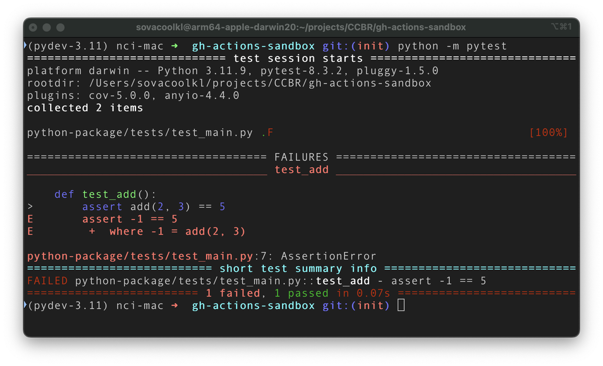

Use GitHub actions to automate.

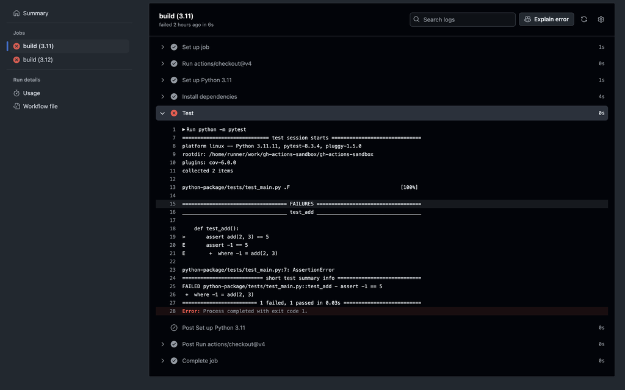

## Testing & validation

Use linters and code quality checks.

- Ensure code is formatted for readability, quality, and syntax is correct.
- Security and vulnerability scanning with GitHub Advanced Security.
- R: `air`. Python: `ruff`.

Use `pre-commit` to run checks automatically on every change.

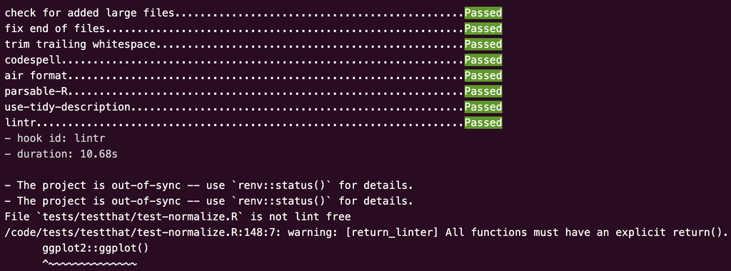

## Document everything

Inline comments, function docstrings, vignettes, tutorials, getting started guide

```
Rscript
```

```r
#' Add together two numbers
#'
#' @param x A number
#' @param y A number
#' @returns The sum of `x` and `y`
#' @examples
#' add(1, 1)
#' add(10, 1)
add <- function(x, y) {
  x + y
}
```

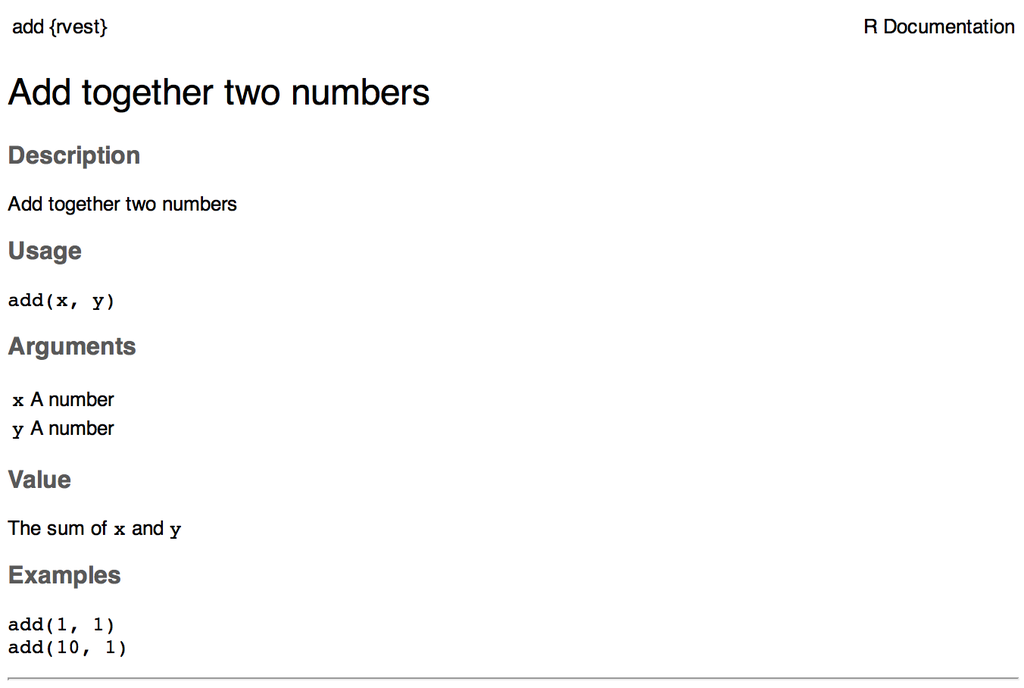

Example from https://r-pkgs.org/man.html

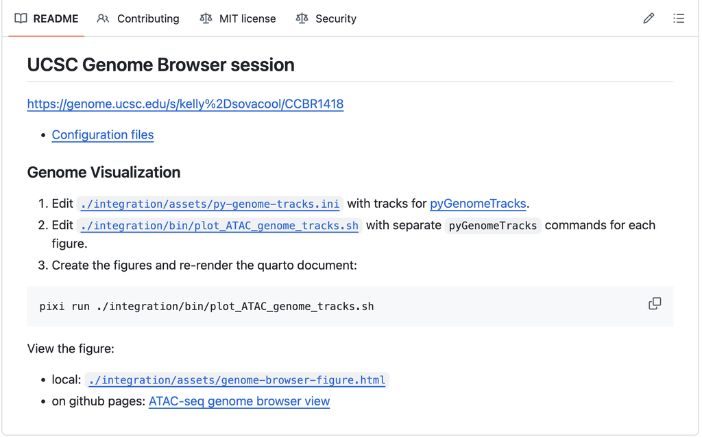

## Document how you are using agents

*from the very beginning of the project:*

Create a document outlining how you will and will *not* use LLMs and agents.

```
docs/ai-usage.md
```

```
- Human responsibilities: Formulate the problem
  statement, design the software,
  validate the results, write the interpretation.
- Agent roles: assist in generating code,
  unit tests, and function documentation.
```

Disclose use of LLMs and agents in commit messages, issue comments, and pull requests.

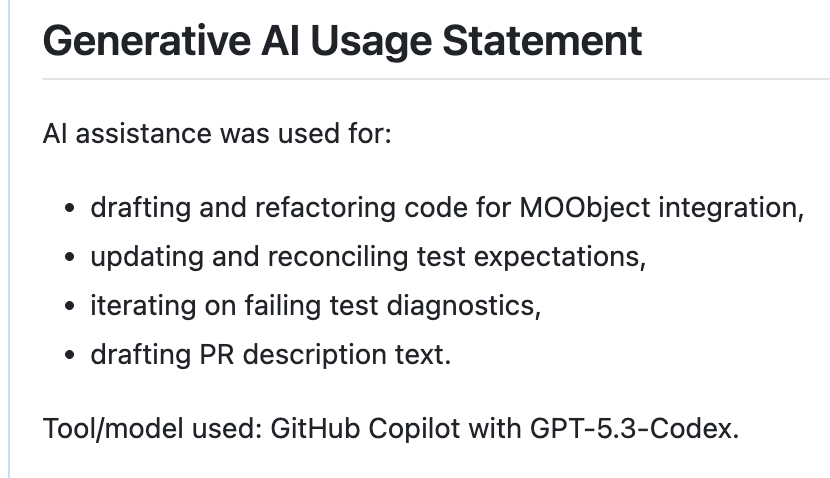

## Responsible agent use to minimize risks

|  | Practice | Risks minimized |
| --- | --- | --- |
|  | Follow reproducible practices | unreproducible work, destructive agent actions |
|  | Review, test, and validate all code | incorrect methods, bugs, inefficiencies, malware |
|  | Document everything | unreadable code, unusable code, lack of transparency |

## A checklist for agent-assisted Bioinformatics

**Check off every item in this checklist before you trust LLM-generated code**

**1. Understand**

- Can I explain what the code is doing?
- Did I review all functions, parameters, and methods?

**2. Test**

- Did I run it on a small or known dataset?
- Did I test edge cases and check expected outputs?
- Have I set up an automated testing framework (pytest, testthat, GitHub Actions)?

**3. Sanity check**

- Do the results make biological sense?
- Did I check for silent problems: missing samples/genes, genome build, coordinates, strandedness, IDs?

**4. Make it reproducible**

- Are code, parameters, software versions/environment, and inputs captured?
- Is the validated code committed & synced with GitHub?

**5. Own it**

- Am I comfortable putting my name on this analysis?
- Have I documented AI use where appropriate?

Checklist credit: Vishal Koparde

## Final reminders

**LLMs produce outputs that *look like* a plausible response to a prompt 🦜**

- View these models as another tool in your toolbox alongside IDEs, HPCs, and other software.
- Interpreting the meaning of the generated outputs is your responsibility. Treat it as a learning experience!

**Agentic tools can accelerate bioinformatics 🚀**

- Just make sure you’re facing the direction you want to go!

## AI Use Statement

- **Human roles**: all text content was written by the author and reviewed by colleagues.
- **Generative AI use**: Copilot was used for reformatting and syntax lookup while drafting this presentation.
- **Images**: image sources are noted on the slides where they appear; images created by others may or may not have used GenAI for assistance. Images listed without a source were created by the author, without GenAI.

## Resources

- [NIH Guidelines for Responsible AI](https://nih.sharepoint.com/sites/NIH-ai/SitePages/Responsible-AI.aspx)
- [BTEP Coding Club](https://bioinformatics.ccr.cancer.gov/docs/btep-coding-club)
- [NIH Library](https://www.nihlibrary.nih.gov/)
- Related talks:
  - [Practical introduction to GenAI](https://bioinformatics.ccr.cancer.gov/btep/classes/a-practical-introduction-to-generative-ai-for-bioinformatics) - BTEP
  - [From Scripts to Skills: Using Generative AI Without Losing Scientific Control](https://bioinformatics.ccr.cancer.gov/btep/classes/from-scripts-to-skills-using-generative-ai-without-losing-scientific-control) - BTEP
  - [Organizing and documenting NGS pipelines on GitHub](https://bioinfo-abcc.ncifcrf.gov/training/event/organizing-and-documenting-ngs-pipelines-on-github-building-549-executive-board-room-nci-frederick-1204241200) - ABCS Programmer’s Corner
- Tutorial: [GitHub Copilot in VS Code](https://ccbr.github.io/HowTos/docs/generative-AI/gh-pilot-vs-code/)
- [GitHub Copilot in VS Code cheat sheet](https://code.visualstudio.com/docs/copilot/reference/copilot-vscode-features)